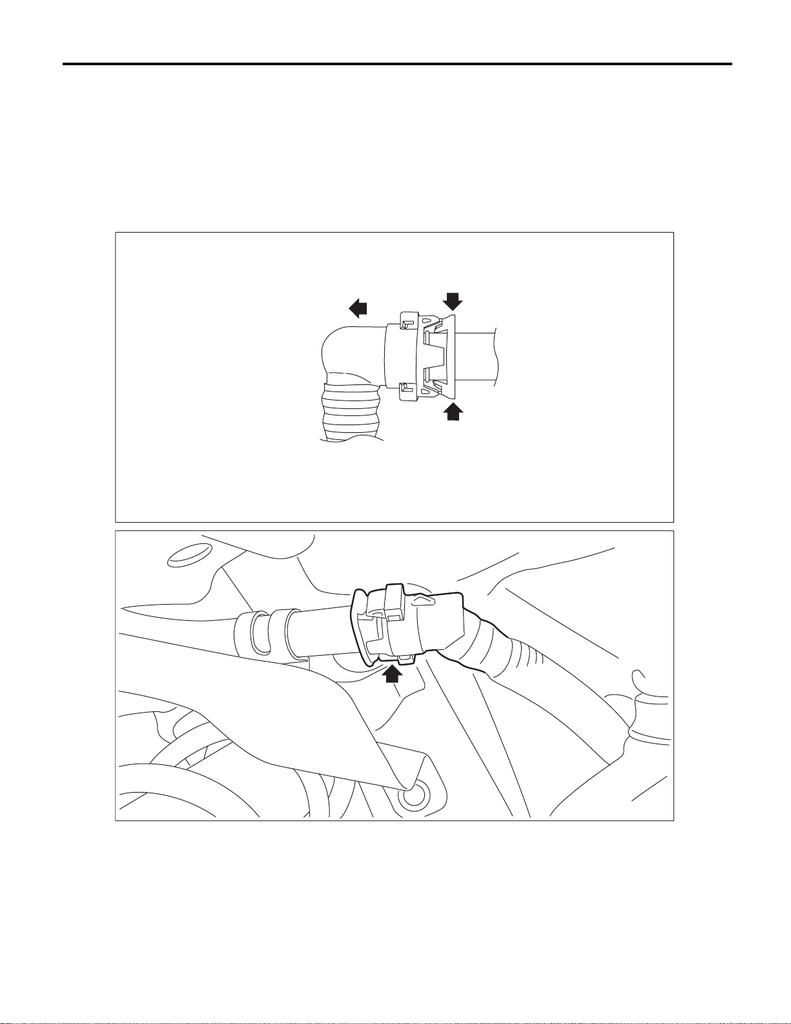

EC(STI)-26

Drain Filter

EMISSION CONTROL (AUX. EMISSION CONTROL DEVICES)

8. Drain Filter

A: REMOVAL

1) Remove the rear wheel LH. <Ref. to WT-5, REMOVAL, Tire and Wheel.>

2) Lift up the vehicle.

3) Remove the rear mud guard LH. <Ref. to EI-23, REMOVAL, Mud Guard.>

4) Disconnect the drain tube from the drain pipe.

NOTE:

Disconnect the quick connector as shown in the figure.

EC-02999

1

1

2

EC-03430

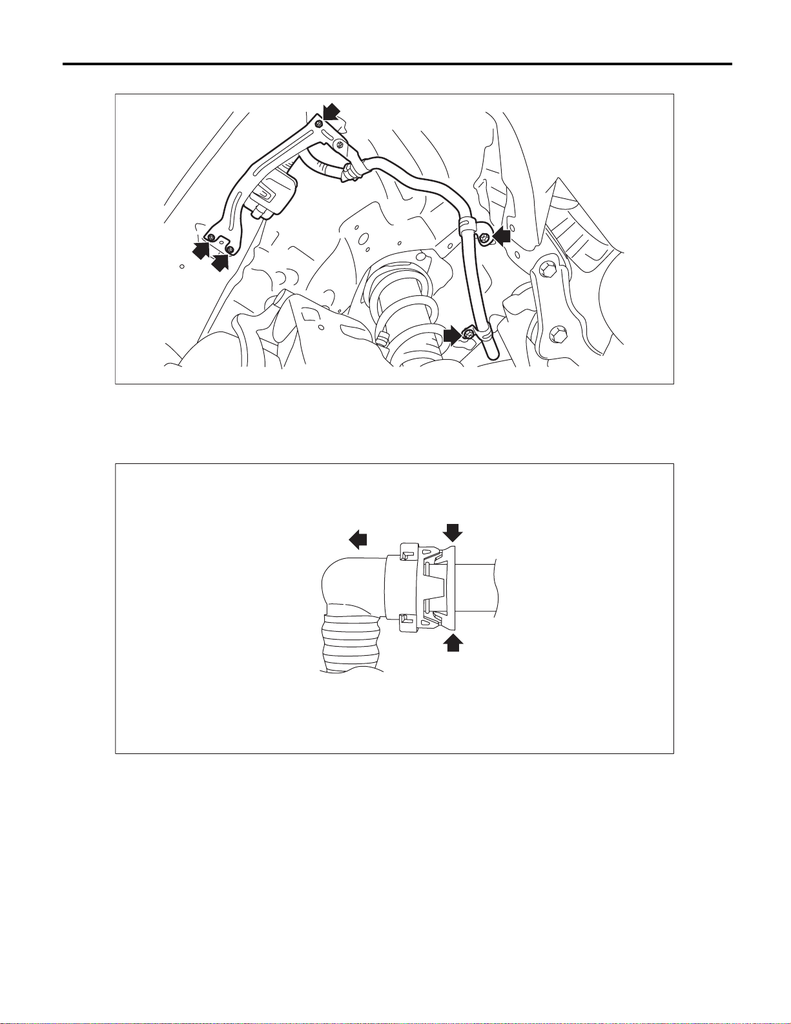

EC(STI)-27

Drain Filter

EMISSION CONTROL (AUX. EMISSION CONTROL DEVICES)

5) Remove the drain bracket and drain pipe from vehicle as a unit.

6) Remove the bolt (A) which holds drain pipe from the drain bracket.

7) Disconnect the drain tube (B) from the drain pipe.

NOTE:

• Disconnect the quick connector as shown in the figure.

EC-03434

EC-02999

1

1

2

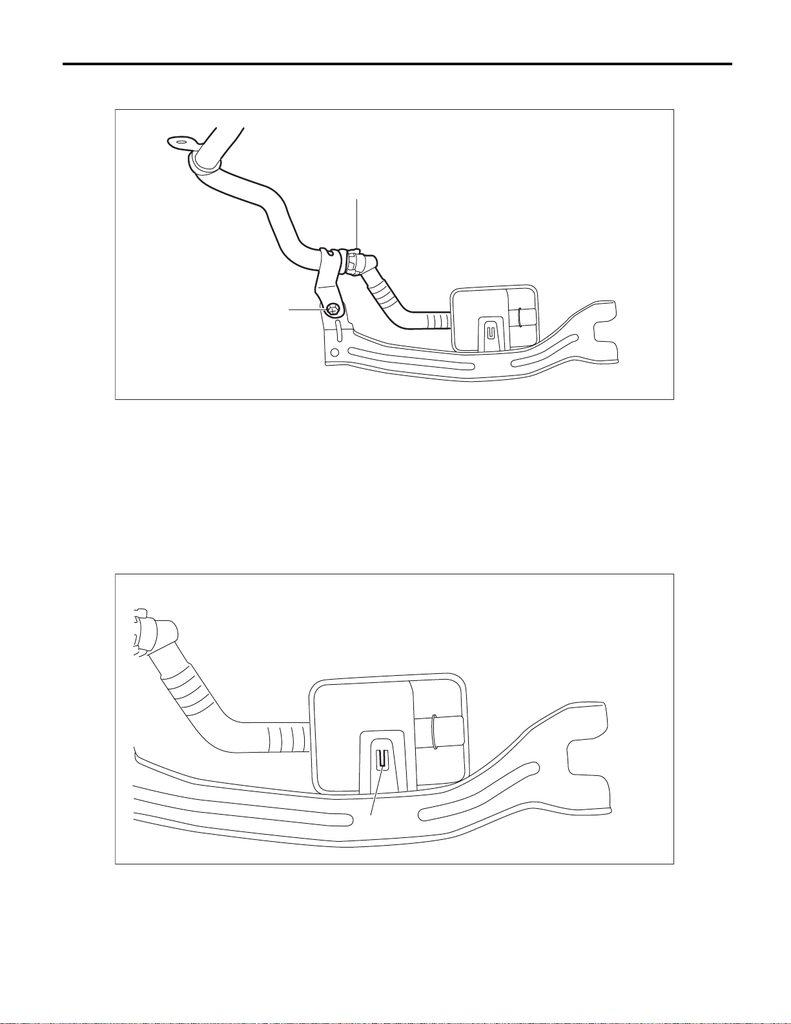

EC(STI)-28

Drain Filter

EMISSION CONTROL (AUX. EMISSION CONTROL DEVICES)

• The drain filter cannot be separated from the drain bracket. Therefore, be sure to replace both of them with

new ones when replacing the drain bracket or drain filter.

B: INSTALLATION

Install in the reverse order of removal.

CAUTION:

• Check that there is no damage or dust on the quick connector. If necessary, clean the seal surface

of the pipe.

• Make sure that the quick connector is securely connected.

NOTE:

• Use a new drain bracket and a drain filter.

• Before installing the drain filter to the drain bracket, check that the claw (a) is securely tightened.

(B)

(A)

EC-03435

(a)

EC-03454

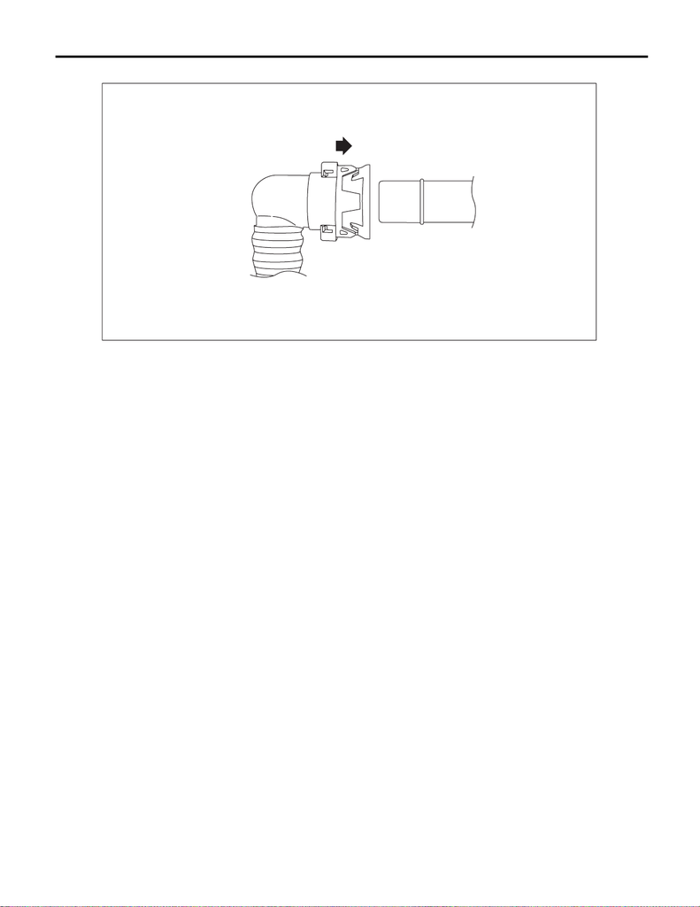

EC(STI)-29

Drain Filter

EMISSION CONTROL (AUX. EMISSION CONTROL DEVICES)

• Install the quick connector as shown in the figure.

Tightening torque:

7.5 N·m (0.8 kgf-m, 5.5 ft-lb)

C: INSPECTION

1) Check that the drain filter has no deformation, cracks or other damages.

2) Check that the tube has no cracks, damage or loose part.

EC-03000